# Tutorial for metabarcode analysis

# 1 Aims

In this repository, you will find the tutotrial explaining how to process metabarcoding data with the `dada2` [suite](https://www.nature.com/articles/nmeth.3869) as implementated in [R](https://benjjneb.github.io/dada2/dada-installation.html) and generate tables of amplicon sequence variants (i.e., ASVs). This tutorial is adapted from the `dada2` [tutorial](https://benjjneb.github.io/dada2/tutorial.html).

# 2 Overview of `dada2` pipeline

The starting point of the `dada2` pipeline is a set of demultiplexed fastq files corresponding to the samples in our amplicon sequencing study. That is, `dada2` expects there to be an individual fastq file for each sample (or two fastq files, one forward and one reverse for each sample). Demultiplexing is often performed at the sequencing center, but if that has not been done there are a variety of tools to accomplish this.  
Once demultiplexed fastq files without non-biological nucleotides are in hand, the `dada2` pipeline proceeds in eight steps as follow:

- Step 1: Inspect read quality profiles
- Step 2: Filtering and trimming
- Step 3: Learn error rates
- Step 4: Dereplicate
- Step 5: Infer sample composition
- Step 6: Merge paired reads
- Step 7: Make sequence table
- Step 8: Remove chimeras

[output not shown]

# 3 Step 1: Inspect read quality profiles

It is important to get a feel for the quality of the data that we are using. To do this, we will plot the quality of samples. These plots allow us to define where the quality of the sequences falls.

| **NOTE:** Plots summarizing the quality of the reads are generated at sample scale. |
| --- |

```bash
#!/bin/bash
#SBATCH --job-name=dada2_01_quality_plot.qsub               # job name
#SBATCH --mail-type=BEGIN,END                               # send a mail at the begining/end of job
#SBATCH --mail-user=balric@sb-roscoff.fr                    # where to send mail
#SBATCH --cpus-per-task 1                                   # number of CPUs required per task
#SBATCH --mem 4GB                                           # memory per processor
#SBATCH --workdir=/shared/projects/indigene/PHYTOPORT/18SV4 # set working directory
#SBATCH -p fast                                             # partition
#SBATCH -o dada2_01_quality_plot.out                        # output file
#SBATCH -e dada2_01_quality_plot.err                        # error file

module load r/4.0.3

srun Rscript /shared/projects/indigene/PHYTOPORT/18SV4/script/dada2_01_quality_plot.R
```

```r
# Section corresponding to the Rscript dada2_01_quality_plot.R #
# ------------------------------------------------------------ #


# Some packages must be installed and loaded
library(dada2)
library(magrittr)
library(ggplot2)


# Set up pathway to forward and reverse fastq files
pathF <- "/shared/projects/indigene/PHYTOPORT/18SV4/FWD"
pathR <- "/shared/projects/indigene/PHYTOPORT/18SV4/REV"

# Create folders for quality profiles
dir.create(paste0(pathF, "/qualityplot"))
dir.create(paste0(pathR, "/qualityplot"))

# Set file paths where quality plots will be stored
filtpathF <- file.path(pathF, "qualityplot")
filtpathR <- file.path(pathR, "qualityplot")

# Get a list of all fastq files in the work directory and separate FWD and REV
# Forward and reverse fastq files have format: SAMPLENAME_Cut1_trimmed.fastq.gz
# and SAMPLENAME_Cut2_trimmed.fastq.gz
fastqFs <- sort(list.files(pathF, pattern = "fastq.gz"))
fastqRs <- sort(list.files(pathR, pattern = "fastq.gz"))

# Select file with a size above to 1000 bytes
fastqFs <- fastqFs[file.size(file.path(pathF, fastqFs)) > 1000]
fastqRs <- fastqRs[file.size(file.path(pathR, fastqRs)) > 1000]
if (length(fastqFs) != length(fastqRs)) {
    stop("Forward and reverse files do not match.")
}

# Identify the name of the run (here one run: PHYTOPORT)
runs <- sub("^PHP_[B, F, H]\\d+_\\d+_\\d+_([^_]+).+$", "\\1", fastqFs) %>% unique

# Quality plots to the sample level
pdf(file.path(filtpathF, "indiv_F_Qplots.pdf"))
for (i in file.path(pathF, fastqFs)[1]) {
    print(plotQualityProfile(i))
}
dev.off()

pdf(file.path(filtpathR, "indiv_R_Qplots.pdf"))
for (i in file.path(pathR, fastqRs)) {
    print(plotQualityProfile(i))
}
dev.off()

# Version of packages used to build this document
sessionInfo()
```

**Visualization example of the quality plot**

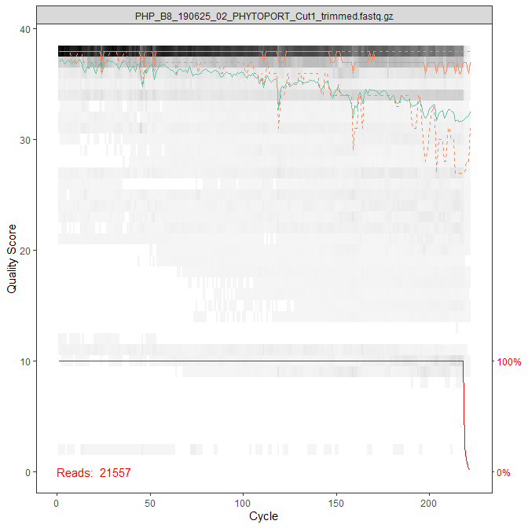

Visualization example of the quality plot

[output not shown]

# 4 Step 2: Filtering and trimming

In sequence data, low-quality sequences can contain unexpected and misleading errors, and Illumina sequencing quality tends to drop off at the end of reads. Therefore, before chosing sequence variants, we trim reads where their quality scores begin to drop (the `truncLen` and `truncQ` values) and remove any low-quality reads that are left over after we have finished trimming (the `maxEE` value).

In `truncLen=c(xxx, yyy)` of the function `filterAndTrim()`, `xxx` refers to the forward read truncation length, whereas `yyy` refers to the reverse read truncation length. These parameters are determined from the inspection of quality profiles.

These parameters should be stored in a .csv file (*dada2_pipeline_parameters.csv*) located in your workspace.

[output not shown]

```bash
#!/bin/bash
#SBATCH --job-name=dad2_02_filter_trim_a.qsub               # job name
#SBATCH --mail-type=BEGIN,END                               # send a mail at the begining/end of job
#SBATCH --mail-user=balric@sb-roscoff.fr                    # where to send mail
#SBATCH --cpus-per-task 4                                   # number of CPUs required per task
#SBATCH --mem 10GB                                          # memory per processor
#SBATCH --workdir=/shared/projects/indigene/PHYTOPORT/18SV4 # set working directory
#SBATCH -p fast                                             # partition
#SBATCH -o dada2_02_filter_trim_a.out                       # output file
#SBATCH -e dada2_02_filter_trim_a.err                       # error file

module load r/4.0.3

srun Rscript /shared/projects/indigene/PHYTOPORT/18SV4/script/dada2_02_filter_trim_a.R
```

```r
# Section corresponding to the Rscript dada2_02_filter_trim_a.R #
# ------------------------------------------------------------- #


# Some packages must be installed and loaded
library(dada2)
library(data.table)
library(magrittr)


# # Set up pathway to forward and reverse fastq files
path <- "/shared/projects/indigene/PHYTOPORT/18SV4"
pathF <- "/shared/projects/indigene/PHYTOPORT/18SV4/FWD"
pathR <- "/shared/projects/indigene/PHYTOPORT/18SV4/REV"

# Create folders for dada2 results
dir.create((paste0(path, "/dada2/log")))

# Load the table of dada2 parameters
dada2_param <- read.csv2(paste0(path, "/dada2_pipeline_parameters.csv"), header = TRUE,
    stringsAsFactors = FALSE)

# Get a list of all fastq files in the work directory and separate FWD and REV
# Forward and reverse fastq files have format: SAMPLENAME_Cut1_trimmed.fastq.gz
# and SAMPLENAME_Cut1_trimmed.fastq.gz
fastqFs <- sort(list.files(pathF, pattern = "fastq.gz"))
fastqRs <- sort(list.files(pathR, pattern = "fastq.gz"))

# Select file with a size above to 1000 bytes
fastqFs <- fastqFs[file.size(file.path(pathF, fastqFs)) > 1000]
fastqRs <- fastqRs[file.size(file.path(pathR, fastqRs)) > 1000]
if (length(fastqFs) != length(fastqRs)) {
    stop("Forward and reverse files do not match.")
}

# Arguments for filter and trim
args <- dada2_param[dada2_param$step == "step01", ]
trunc_fwd <- args[args$vairable == "TRUNC_FWD", 3] %>% as.numeric
trunc_rev <- args[args$vairable == "TRUNC_REV", 3] %>% as.numeric
maxee <- args[args$vairable == "MAXEE", 3] %>% as.numeric

# Set file paths where files will be stored
pathF <- "/shared/projects/indigene/PHYTOPORT/18SV4/FWD"
pathR <- "/shared/projects/indigene/PHYTOPORT/18SV4/REV"
filtpathF <- file.path(pathF, "filtered")
filtpathR <- file.path(pathR, "filtered")

# Filtering and trimming
for (i in fastqFs) {
    out <- dada2::filterAndTrim(fwd = file.path(pathF, i), filt = file.path(filtpathF,
        i), rev = file.path(pathR, i), filt.rev = file.path(filtpathR, i), truncLen = c(trunc_fwd,
        trunc_rev), maxEE = maxee, maxN = 0, compress = TRUE, verbose = TRUE, multithread = FALSE)

    # Save filtered and trimmed table in the folder of dada2 results
    data.table(out, keep.rownames = TRUE) %>% setnames(names(data.table(out, keep.rownames = TRUE))[1],
        c("sample")) %>% fwrite(paste0(path, "/dada2/log/filter_", sub("_trimmed.+$",
        "", basename(i)), ".csv"), sep = ";", col.names = TRUE)
    rm(out)
}

# Version of packages used to build this document
sessionInfo()
```

[output not shown]

```bash
#!/bin/bash
#SBATCH --job-name=dada2_02_filter_trim_b.qsub              # job name
#SBATCH --mail-type=BEGIN,END                               # send a mail at the begining/end of job
#SBATCH --mail-user=balric@sb-roscoff.fr                    # where to send mail
#SBATCH --cpus-per-task 1                                   # number of CPUs required per task
#SBATCH --mem 4GB                                           # memory per processor
#SBATCH --workdir=/shared/projects/indigene/PHYTOPORT/18SV4 # set working directory
#SBATCH -p fast                                             # partition
#SBATCH -o dada2_02_filter_trim_b.out                       # output file
#SBATCH -e dada2_02_filter_trim_b.err                       # error file

module load r/4.0.3

srun Rscript /shared/projects/indigene/PHYTOPORT/18SV4/script/dada2_02_filter_trim_b.R
```

```r
# Section corresponding to the Rscript dada2_02_filter_trim_b.R #
# ------------------------------------------------------------- #


# Some packages must be installed and loaded
library(data.table)
library(magrittr)


# Merge all files in one table
path <- "/shared/projects/indigene/PHYTOPORT/18SV4/dada2/log"
myfiles <- list.files(path = path, pattern = "*.csv", full.names = TRUE)
filter <- lapply(myfiles, read.csv2)
filter <- do.call("rbind", filter)
filter %>% data.table() %>% fwrite(paste0(path, "/filter.csv"), sep = ";", col.names = TRUE)

# Version of packages used to build this document
sessionInfo()
```

# 5 Step 3: Learn error rates

Errors can be introduced by PCR amplification and sequencing. In this part of the pipeline `dada2` will learn to distinguish error from biological differences using a subset of our data as a training set. The `learnErrors()` method learns this error model from the data, by alternating estimation of the error rates and inference of sample composition until they converge on a jointly consistent solution. he error parameters typically vary between sequencing runs and PCR protocols, so this method provides a way to estimate those parameters from the data itself.

```bash
#!/bin/bash
#SBATCH --job-name=dada2_03_learn_error.qsub                # job name
#SBATCH --mail-type=BEGIN,END                               # send a mail at the begining/end of job
#SBATCH --mail-user=balric@sb-roscoff.fr                    # where to send mail
#SBATCH --cpus-per-task 6                                   # number of CPUs required per task
#SBATCH --mem 10GB                                          # memory per processor
#SBATCH --workdir=/shared/projects/indigene/PHYTOPORT/18SV4 # set working directory
#SBATCH -p fast                                             # partition
#SBATCH -o dada2_03_learn_error.out                         # output file
#SBATCH -e dada2_03_learn_error.err                         # error file

module load r/4.0.3

srun Rscript /shared/projects/indigene/PHYTOPORT/18SV4/script/dada2_03_learn_error.R
```

```r
# Section corresponding to the Rscript dada2_03_learn_error.R #
# ----------------------------------------------------------- #


# Some packages must be installed and loaded
library(dada2)
library(data.table)
library(doParallel)
library(foreach)
library(magrittr)
registerDoParallel(cores = 6)


# Load the table of dada2 parameters
path <- "/shared/projects/indigene/PHYTOPORT/18SV4"
dada2_param <- read.csv2(paste0(path, "/dada2_pipeline_parameters.csv"), header = TRUE,
    stringsAsFactors = FALSE)

# Define the following path variable so that it points to the extracted directory
pathF <- "/shared/projects/indigene/PHYTOPORT/18SV4/FWD"
pathR <- "/shared/projects/indigene/PHYTOPORT/18SV4/REV"

# Arguments for denoising and merging
args <- dada2_param[dada2_param$step == "step02", ]
min_read_nb <- args[args$vairable == "MIN_READ_NUM", 3]

# Track reads through the pipeline As a final check of our progress, we'll look
# at the number of reads that made it through each step in the pipeline
getN <- function(x) sum(getUniques(x))
getA <- function(x) length(getUniques(x))

# selection based on the number of reads
tmp <- fread(paste0(path, "/dada2/log/filter.csv"))
tmpR <- tmpF <- tmp[reads.out >= min_read_nb, sample]

# Identify the name of the run (here one run: PHYTOPORT)
runs <- sub("^PHP_[B, F, H]\\d+_\\d+_\\d+_([^_]+).+$", "\\1", tmp$sample) %>% unique
runs <- c(paste(runs, "Cut1", sep = "_"), paste(runs, "Cut2", sep = "_"))

# File parsing
filtpathF <- file.path(pathF, "filtered")
filtpathR <- file.path(pathR, "filtered")
filtFsall <- paste(filtpathF, tmpF, sep = "/")
filtRsall <- paste(filtpathR, tmpR, sep = "/")
sample.names.all <- sub("_trimmed.+$", "", basename(filtFsall))
sample.namesR.all <- sub("_trimmed.+$", "", basename(filtRsall))
if (!identical(sample.names.all, sample.namesR.all)) {
    stop("Forward and reverse files do not match.")
}
names(filtFsall) <- sample.names.all
names(filtRsall) <- sample.names.all

# Set seed to ensure that randomized steps are replicatable
set.seed(100)

# Loop allowing to determinate learn error rates and infer sample composition
foreach(i = runs, .packages = c("data.table", "dada2")) %dopar% {
    filtFs <- filtFsall[grep(i, names(filtFsall))]
    filtRs <- filtRsall[grep(i, names(filtRsall))]
    sample.names <- sub("_trimmed.+$", "", basename(filtFs))
    # Learn forward error rates
    errF <- learnErrors(filtFs, nbases = 1e+08, multithread = FALSE)
    pdf(paste0("dada2/log/errF_", i, ".pdf"))
    print(plotErrors(errF, nominalQ = TRUE))
    dev.off()
    # Learn reverse error rates
    errR <- learnErrors(filtRs, nbases = 1e+08, multithread = FALSE)
    pdf(paste0("dada2/log/errR_", i, ".pdf"))
    print(plotErrors(errR, nominalQ = TRUE))
    dev.off()
    save(errF, file = paste0(path, "/dada2/log/errF_", i, ".rda"))  # CHANGE ME to where you want learn error models to be saved
    save(errR, file = paste0(path, "/dada2/log/errR_", i, ".rda"))  # CHANGE ME to where you want learn error models to be saved
}

# Version of packages used to build this document
sessionInfo()
```

**Visualization example of the estimates error rates**

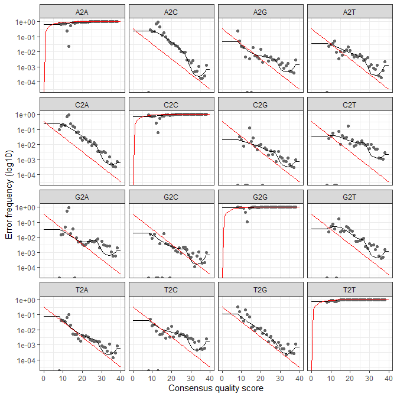

Visualization example of the estimates error rates

[output not shown]

# 6 Steps 4-7: Denoising, and merging

After it understands the error rates, a dereplication step is required to condense the data by collapsing together all reads that encode the same sequence, which significantly reduces later computation times. Then, using the dereplicated data and error rates, `dada2` will infer the ASVs in our data.

| **NOTE:** In `dada` algorithm, for each run, the samples are pooled together with the argument `pool` = TRUE, which can increase the sensitivity to rare variants. |
| --- |

Finally, we will merge the corresponding forqard and reverse reads to create a list of the fully denoised sequences and create a sequence table for the result.

[output not shown]

```bash
#!/bin/bash
#SBATCH --job-name=dada2_04_denoising_merging.qsub          # job name
#SBATCH --mail-type=BEGIN,END                               # send a mail at the begining/end of job
#SBATCH --mail-user=balric@sb-roscoff.fr                    # where to send mail
#SBATCH --cpus-per-task 6                                   # number of CPUs required per task
#SBATCH --mem 10GB                                          # memory per processor
#SBATCH --workdir=/shared/projects/indigene/PHYTOPORT/18SV4 # set working directory
#SBATCH -p fast                                             # partition
#SBATCH -o dada2_04_denoising_merging.out                   # output file
#SBATCH -e dada2_04_denoising_merging.err                   # error file

module load r/4.0.3

srun Rscript /shared/projects/indigene/PHYTOPORT/18SV4/script/dada2_04_denoising_merging.R
```

```r
# Section corresponding to the Rscript dada2_04_denoising_merging.R #
# ----------------------------------------------------------------- #


# Some packages must be installed and loaded
library(dada2)
library(data.table)
library(doParallel)
library(foreach)
library(magrittr)
registerDoParallel(cores = 6)


# Load the table of dada2 parameters
path <- "/shared/projects/indigene/PHYTOPORT/18SV4"
dada2_param <- read.csv2(paste0(path, "/dada2_pipeline_parameters.csv"), header = TRUE,
    stringsAsFactors = FALSE)

# Define the following path variable so that it points to the extracted directory
pathF <- "/shared/projects/indigene/PHYTOPORT/18SV4/FWD"
pathR <- "/shared/projects/indigene/PHYTOPORT/18SV4/REV"
pathErr <- "/shared/projects/indigene/PHYTOPORT/18SV4/dada2/log"

# Arguments for denoising and merging
args <- dada2_param[dada2_param$step == "step02", ]
min_read_nb <- args[args$vairable == "MIN_READ_NUM", 3]

# Track reads through the pipeline As a final check of our progress, we'll look
# at the number of reads that made it through each step in the pipeline
getN <- function(x) sum(getUniques(x))
getA <- function(x) length(getUniques(x))

# selection based on the number of reads
tmp <- fread(paste0(path, "/dada2/log/filter.csv"))
tmpR <- tmpF <- tmp[reads.out >= min_read_nb, sample]

# Identify the name of the run (here one run: PHYTOPORT)
runs <- sub("^PHP_[B, F]\\d+_\\d+_\\d+_([^_]+).+$", "\\1", tmp$sample) %>% unique
runs <- c(paste(runs, "Cut1", sep = "_"), paste(runs, "Cut2", sep = "_"))

# File parsing
filtpathF <- file.path(pathF, "filtered")
filtpathR <- file.path(pathR, "filtered")
filtFsall <- paste(filtpathF, tmpF, sep = "/")
filtRsall <- paste(filtpathR, tmpR, sep = "/")
sample.names.all <- sub("_trimmed.+$", "", basename(filtFsall))
sample.namesR.all <- sub("_trimmed.+$", "", basename(filtRsall))
if (!identical(sample.names.all, sample.namesR.all)) {
    stop("Forward and reverse files do not match.")
}
names(filtFsall) <- sample.names.all
names(filtRsall) <- sample.names.all
filtErr <- sort(list.files(pathErr, pattern = ".rda"))

# Set seed to ensure that randomized steps are replicatable
set.seed(100)

# Loop allowing to determinate learn error rates and infer sample composition
foreach(i = runs, .packages = c("data.table", "dada2")) %dopar% {
    filtFs <- filtFsall[grep(i, names(filtFsall))]
    filtRs <- filtRsall[grep(i, names(filtRsall))]
    sample.names <- sub("_trimmed.+$", "", basename(filtFs))
    # Select the FWD and REV error files
    err <- filtErr[grep(i, filtErr)]
    load(paste(pathErr, err[grep("errF", err)], sep = "/"))
    load(paste(pathErr, err[grep("errR", err)], sep = "/"))
    # Sample inference and merger of paired-end reads
    mergers <- vector("list", length(sample.names))
    names(mergers) <- sample.names
    track <- vector("list", length(sample.names))
    names(track) <- sample.names
    for (sam in sample.names) {
        cat("Processing:", sam, "\n")
        # Dereplication of forward reads+
        derepF <- derepFastq(filtFs[[sam]])
        # Infer sample composition of forward reads
        ddF <- dada(derepF, err = errF, multithread = FALSE, pool = TRUE)
        # Dereplication of revers reads
        derepR <- derepFastq(filtRs[[sam]])
        # Infer sample composition of reverse reads
        ddR <- dada(derepR, err = errR, multithread = FALSE, pool = TRUE)
        # Merge forward/reverse reads
        merger <- mergePairs(ddF, derepF, ddR, derepR, trimOverhang = TRUE, verbose = TRUE)
        mergers[[sam]] <- merger
        track[[sam]] <- data.table(sample = sam, denoisedF.read = getN(ddF), denoisedR.read = getN(ddR),
            merged.read = getN(merger), denoisedF.seq = getA(ddF), denoisedR.seq = getA(ddR),
            merged.seq = getA(merger))
    }
    rm(derepF)
    rm(derepR)
    # Construct sequence table
    track <- rbindlist(track)
    seqtab <- makeSequenceTable(mergers)
    saveRDS(track, paste0(path, "/dada2/log/track_", i, ".rds"))  # CHANGE ME to where you want sequence table to be saved
    saveRDS(seqtab, paste0(path, "/dada2/seqtab_", i, ".rds"))  # CHANGE ME to where you want sequence table to be saved
    rm(track)
    rm(seqtab)
    for (i in 1:length(mergers)) {
        mergers[[i]] <- data.frame(samples = names(mergers)[i], mergers[[i]])
    }
    mergers <- rbindlist(mergers)
    saveRDS(mergers, paste0(path, "/dada2/log/mergers_", i, ".rds"))  # CHANGE ME to where you want merged table to be saved
}

# Version of packages used to build this document
sessionInfo()
```

# 7 Step 8: Remove Chimeras

Although `dada2` has searched for indel errors and substitutions, there may still be chimeric sequences in our dataset that are another important source of spurious sequences in amplicon sequencing. Chimeras are sequences that are derived form forward and reverse sequences from two different organisms becoming fused together during PCR and/or sequencing. To identify chimeras, we search for rare sequences variants that can be reconstructed by combining left-hand and right-hand segments from two more abudant "parent" sequences.

| **NOTE:** The chimera detection method has to be `pooled` instead of `consensus`. |
| --- |

```bash
#!/bin/bash
#SBATCH --job-name=dada2_05_chimeras.qsub                   # job name
#SBATCH --mail-type=BEGIN,END                               # send a mail at the begining/end of job
#SBATCH --mail-user=balric@sb-roscoff.fr                    # where to send mail
#SBATCH --cpus-per-task 4                                   # number of CPUs required per task
#SBATCH --mem 100GB                                         # memory per processor
#SBATCH --workdir=/shared/projects/indigene/PHYTOPORT/18SV4 # set working directory
#SBATCH -p fast                                             # partition
#SBATCH -o dada2_05_chimeras.out                            # output file
#SBATCH -e dada2_05_chimeras.err                            # error file

module load r/4.0.3

srun Rscript /shared/projects/indigene/PHYTOPORT/18SV4/script/dada2_05_chimeras.R
```

```r
# Section corresponding to the Rscript dada2_05_chimeras.R #
# -------------------------------------------------------- #


# Some packages must be installed and loaded
library(dada2)
packageVersion("dada2")
library(data.table)
library(magrittr)
library(digest)


# Define the following path variable so that it points to the extracted directory
pathFilt <- "/shared/projects/indigene/PHYTOPORT/18SV4/dada2/log"

# Merge multiple runs (if necessary)
x <- grep("seqtab_.+\\.rds$", dir("/shared/projects/indigene/PHYTOPORT/18SV4/dada2/"),
    value = TRUE)
x <- paste0("/shared/projects/indigene/PHYTOPORT/18SV4/dada2/", x)
st.all <- mergeSequenceTables(tables = x)

# Remove chimeras
seqtab.nochim <- removeBimeraDenovo(st.all, method = "pooled", multithread = TRUE)
seqtab.nochim2 <- seqtab.nochim %>% t %>% data.table

# load statistics
x <- grep("track_.+\\.rds$", dir("/shared/projects/indigene/PHYTOPORT/18SV4/dada2/log/"),
    value = TRUE)
x <- paste0("/shared/projects/indigene/PHYTOPORT/18SV4/dada2/log/", x)

stattab <- lapply(x, readRDS) %>% rbindlist

stattab[, `:=`(nochim.read, sapply(sample, function(X) {
    sum(seqtab.nochim2[, get(X)])
}))]

stattab[, `:=`(nochim.seq, sapply(sample, function(X) {
    sum(seqtab.nochim2[, get(X)] != 0)
}))]

stattab <- stattab[, list(sample, denoisedF.read, denoisedR.read, merged.read, nochim.read,
    denoisedF.seq, denoisedR.seq, merged.seq, nochim.seq)]

filter <- read.csv2(paste0(pathFilt, "/filter.csv"), header = TRUE, stringsAsFactors = FALSE)
filter$sample <- sub("_trimmed.+$", "", filter$sample)
stattab <- merge(stattab, filter, by.x = "sample", by.y = "sample")
stattab <- stattab[, c("sample", "reads.in", "reads.out", "denoisedF.read", "denoisedR.read",
    "merged.read", "nochim.read", "denoisedF.seq", "denoisedR.seq", "merged.seq",
    "nochim.seq")]
fwrite(stattab, "/shared/projects/indigene/PHYTOPORT/18SV4/dada2/log/statistics.tsv",
    sep = "\t")

rm(stattab, seqtab.nochim2)

# Construct sequence table
tmp <- seqtab.nochim %>% t %>% data.table(keep.rownames = TRUE)
setnames(tmp, "rn", "sequence")
rm(seqtab.nochim)
tmp <- data.table(amplicon = sapply(tmp[, sequence], digest, algo = "sha1"), tmp)
fwrite(tmp, "/shared/projects/indigene/PHYTOPORT/18SV4/dada2/seqtab_all.tsv", sep = "\t")

# Version of packages used to build this document
sessionInfo()
```

[output not shown]

# 8 Step 9: Assign taxonomy

The `dada2` package provides a native implementation of the [naive Bayesian classifer method](https://aem.asm.org/content/73/16/5261.long) for this purpose. But the recently developed `IdTaxa` taxonomic classification method, available via the [DECIPHER Bioconductor package](https://bioconductor.org/packages/release/bioc/html/DECIPHER.html) have [classification performance that is better than the long-time standard set by the naive Bayesian classifer](https://microbiomejournal.biomedcentral.com/articles/10.1186/s40168-018-0521-5). Hence, we used IDTAXA algorithm for taxonomic assignment.

| **NOTE:** Trained classifers are available from [http://DECIPHER.codes/Downloads.html](http://www2.decipher.codes/Downloads.html). Download the PR2 18S v4.13 and SILVA SSU r138 (modified). |
| --- |

```bash
#!/bin/bash
#SBATCH --job-name=dada2_06_IdTaxa_pr2.qsub                 # job name
#SBATCH --mail-type=BEGIN,END                               # send a mail at the end of job
#SBATCH --mail-user=balric@sb-roscoff.fr                    # where to send mail
#SBATCH --cpus-per-task 6                                   # number of CPUs required per task
#SBATCH --mem 100GB                                         # memory per processor
#SBATCH --workdir=/shared/projects/indigene/PHYTOPORT/18SV4 # set working directory
#SBATCH -p fast                                             # partition
#SBATCH -o dada2_06_IdTaxa_pr2.out                          # output file
#SBATCH -e dada2_06_IdTaxa_pr2.err                          # error file

module load r/4.0.3

srun Rscript /shared/projects/indigene/PHYTOPORT/18SV4/script/dada2_06_IdTaxa_silva.R
```

```r
# Section corresponding to the Rscript dada2_06_IdTaxa_pr2.R #
# ---------------------------------------------------------- #


# Some packages must be installed and loaded
library(dada2)
packageVersion("dada2")
library(data.table)
library(DECIPHER)


# Define the following path variable so that it points to the extracted directory
pathSeq <- "/shared/projects/indigene/PHYTOPORT/18SV4/dada2"
pathRef <- "/shared/projects/indigene/refdb"

# Load sequence table
seqtab.nochim <- read.table(paste0(pathSeq, "/seqtab_all.tsv"), header = TRUE)

# Load 18S rDNA references sequences data
load(paste0(pathRef, "/PR2_v4_13_March2021.RData"))

# Create a DNAStringSet from the ASVs
seqvector <- as.character(seqtab.nochim$sequence)
dna <- DNAStringSet(seqvector)

# Add names to sequences
dna@ranges@NAMES <- as.character(seqtab.nochim$amplicon)

# Classify the sequences
ids <- IdTaxa(dna, trainingSet, type = "extended", strand = "top", processors = 8,
    verbose = FALSE)  # use all processors
# fwrite(ids,
# '/shared/projects/indigene/PHYTOPORT/18SV4/dada2/seqtab_all_taxopr2.tsv', sep =
# '\t')
save(ids, file = paste0(pathSeq, "/seqtab_all_taxopr2.rda"))

# Version of packages used to build this document
sessionInfo()
```

# 9 Step 10: Final ASV table

The ASV table and the taxonomy are merged together.

```bash
#!/bin/bash
#SBATCH --job-name=dada2_07_ASV_table_pr2.qsub              # job name
#SBATCH --mail-type=BEGIN,END                               # send a mail at the begining/end of job
#SBATCH --mail-user=balric@sb-roscoff.fr                    # where to send mail
#SBATCH --cpus-per-task 1                                   # number of CPUs required per task
#SBATCH --mem 4GB                                           # memory per processor
#SBATCH --workdir=/shared/projects/indigene/PHYTOPORT/18SV4 # set working directory
#SBATCH -p fast                                             # partition
#SBATCH -o dada2_07_ASV_table_pr2.out                       # output file
#SBATCH -e dada2_07_ASV_table_pr2.err                       # error file

module load r/4.0.3

srun Rscript /shared/projects/indigene/PHYTOPORT/18SV4/script/dada2_07_ASV_table_pr2.R
```

```r
# Section corresponding to the Rscript dada2_07_ASV_table_pr2.R #
# ------------------------------------------------------------- #


# Some packages must be installed and loaded
library(dplyr)
library(tidyr)
library(data.table)


# Useful function
ASV_func <- function(annot, ASVt, id, vtot, vocc) {
    # Calculate the abundance of each read
    total <- apply(ASVt[, grep(id, colnames(ASVt))], 1, sum)
    # calculate the occurrence of each read
    occurrence <- apply(ASVt[, grep(id, colnames(ASVt))], 1, function(x) sum(x >
        0))
    # Modify the shape of variables taxon, confidence and rank
    for (i in 1:length(annot)) {
        annot[[i]]$taxon <- paste(annot[[i]]$taxon, collapse = "|")
        annot[[i]]$taxon <- sub("Root\\|", "", annot[[i]]$taxon)
        annot[[i]]$confidence <- round(annot[[i]]$confidence[length(annot[[i]]$confidence)],
            digits = 1)
        annot[[i]]$rank <- paste(annot[[i]]$rank, collapse = "|")
        annot[[i]]$rank <- sub("rootrank\\|", "", annot[[i]]$rank)
    }
    # Make one data.table from a list and rename and reorder the columns of table
    annot1 <- rbindlist(annot) %>% mutate(amplicon = names(annot)) %>% dplyr::rename(identity = confidence,
        taxonomy = taxon) %>% relocate(amplicon, taxonomy, rank, identity)
    # Merge for each ASv taxonomic annotation and abundance
    ASV_table <- merge(annot1, ASVt, by.x = "amplicon", by.y = "amplicon", all.x = TRUE) %>%
        mutate(total = total) %>% mutate(occurrence = occurrence) %>% relocate(amplicon,
        taxonomy, rank, identity, sequence, total, occurrence, PHP_B8_190328_02_PHYTOPORT_Cut1:PHP_H42_200304_3_PHYTOPORT_Cut2)
    # Vector with the name each sample
    tmp <- grep(id, colnames(ASV_table), value = TRUE) %>% sub("_Cut\\d$", "", .) %>%
        unique
    # sum for each sample Cut1 and Cut2 values
    for (i in tmp) {
        x <- grep(i, colnames(ASV_table), value = TRUE)
        ASV_table[, `:=`((i), rowSums(.SD)), .SDcols = x]
        ASV_table[, `:=`((x), NULL)]
    }
    #
    setnames(ASV_table, sub(paste0("_", id), "", colnames(ASV_table)))
    ASV_table_filtered <- ASV_table[total >= vtot & occurrence >= vocc][order(total,
        decreasing = TRUE)]
    return(ASV_table_filtered)
}

# Define the following path variable so that it points to the extracted directory
pathTab <- "/shared/projects/indigene/PHYTOPORT/18SV4/dada2"

# Load taxonomy assignment table
load(paste0(pathTab, "/seqtab_all_taxopr2.rda"))
seqtab_nochim <- read.table(paste0(pathTab, "/seqtab_all.tsv"), header = TRUE)

# Building of the annotated ASV table
ASV_phytoport_pr2 <- ASV_func(annot = ids, ASVt = seqtab_nochim, id = "PHYTOPORT",
    vtot = 2, vocc = 1)
fwrite(ASV_phytoport_pr2, "/shared/projects/indigene/PHYTOPORT/18SV4/dada2/seqtab_all_taxo_final.tsv",
    sep = "\t")

# Version of packages used to build this document
sessionInfo()
```